# Series de tiempo

Luis Apáez

27/03/2022

# Ejemplo práctico (parte I)

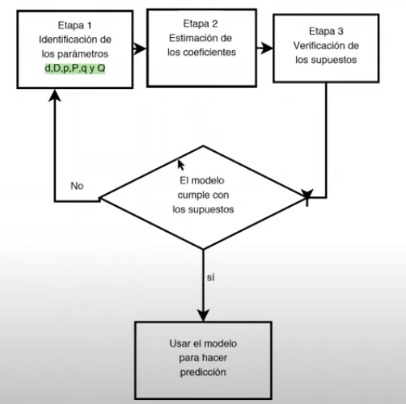

Img1

Comenzamos trabajando con la serie de tiempo almacenada en `Airpassengers` (número de viajes mensuales en aerolíneas en EU). Lo primero que haremos será visualizar los datos

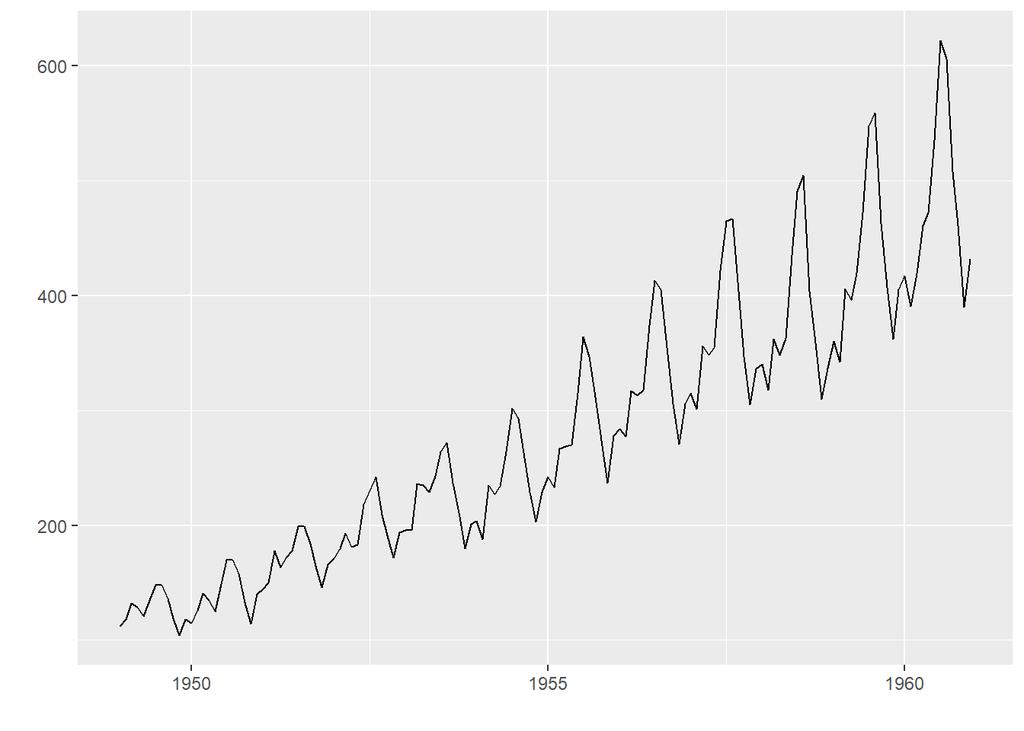

```r
autoplot(AirPassengers)
```

donde notamos un período de 12 y vemos que la varianza es creciente. De tal manera podemos realizar una transformación logarítmica para estabilizar la varianza

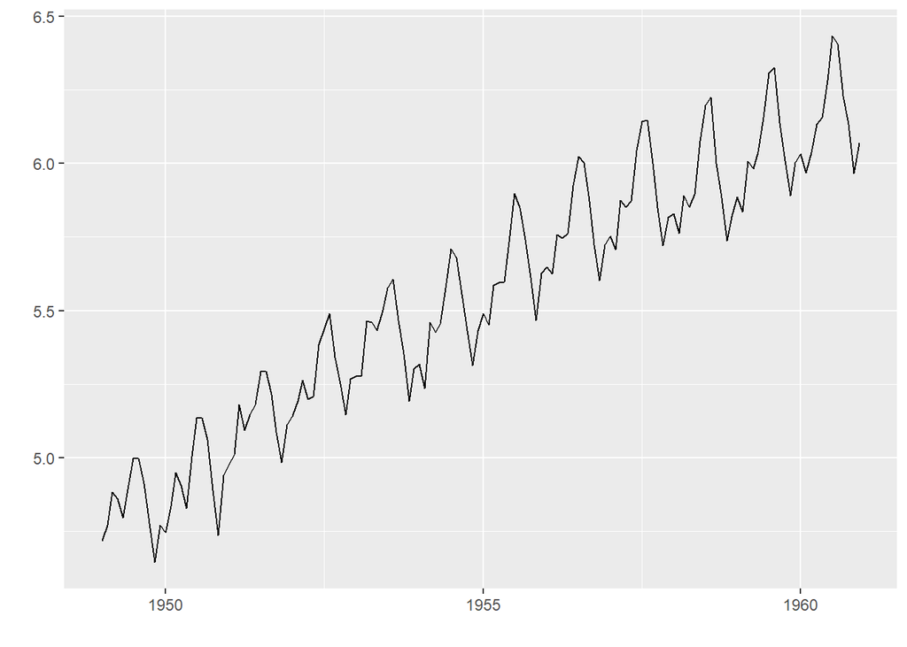

```r
autoplot(log(AirPassengers))
```

## Caso 1: Trabajar con la ST sin transformar

Podemos aplicar de forma directa la función `auto.arima` como sigue:

```r
fit_auto <- auto.arima(AirPassengers)
fit_auto
```

```
## Series: AirPassengers
## ARIMA(2,1,1)(0,1,0)[12]
##
## Coefficients:
##          ar1     ar2      ma1
##       0.5960  0.2143  -0.9819
## s.e.  0.0888  0.0880   0.0292
##
## sigma^2 = 132.3:  log likelihood = -504.92
## AIC=1017.85   AICc=1018.17   BIC=1029.35
```

donde el modelo “propuesto” es $ARIMA(2,1,1)(0,1,0)_{12}$.

Recordemos que uno de los supuestos hechos es que estamos trabajando con un ruido blanco $\{Z_{t}\}$, lo cual implica que tenemos varianza constante, normalidad y no correlación en dicho proceso. Para analizar este proceso trabajaremos con los residuales del modelo ($e_{i}=y_{i}-\hat{y_{i}}$). Donde puede decirse que los residuales son una estimación del ruido blanco.

De tal manera, procedemos a analizar los residuales:

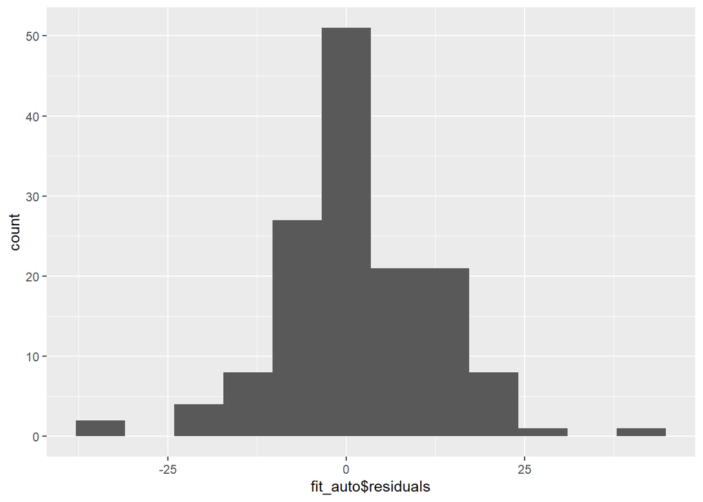

```r
ggplot(fit_auto, aes(x=fit_auto$residuals)) + geom_histogram(bins=12)
```

y/o analizamos la qqplot correspondiente

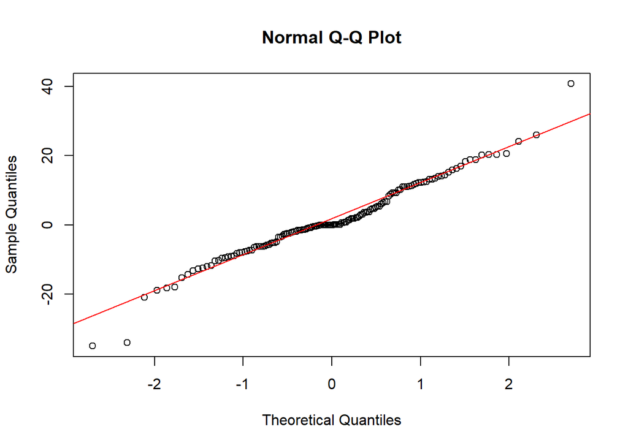

```r
qqnorm(fit_auto$residuals)
qqline(fit_auto$residuals, col="red")
```

donde parece ser que los residuales si siguen una distribución normal aunque vemos ciertos sectores donde los puntos no siguen la recta roja referente a la normalidad. Podemos hacer también pruebas de hipótesis:

**Prueba de Anderson-Darling**

```r
ad.test(fit_auto$residuals)
```

```
##
##  Anderson-Darling normality test
##
## data:  fit_auto$residuals
## A = 1.2105, p-value = 0.003601
```

donde se rechaza $H_{0}$, es decir, es plausible asumir que los residuales no siguen una distribución normal.

Veamos ahora pruebas sobre la varianza constante:

```r
# Preparamos los valores
Y <- as.numeric(fit_auto$residuals)
X <- 1:length(fit_auto$residuals)

# Hacemos una prueba no paramétrica
bptest(Y ~ X)
```

```
##
##  studentized Breusch-Pagan test
##
## data:  Y ~ X
## BP = 12.75, df = 1, p-value = 0.0003559
```

donde $H_{0}$ representa que la varianza es constante. Vemos que rechazamos $H_{0}$, por lo que la varianza tampoco es constante. Podemos realizar una prueba alternativa

```r
ncvTest(lm(Y~X))
```

```
## Non-constant Variance Score Test
## Variance formula: ~ fitted.values
## Chisquare = 22.81394, Df = 1, p = 1.7847e-06
```

donde también se rechaza $H_{0}$.

Para verificar la independencia graficamos los residuales

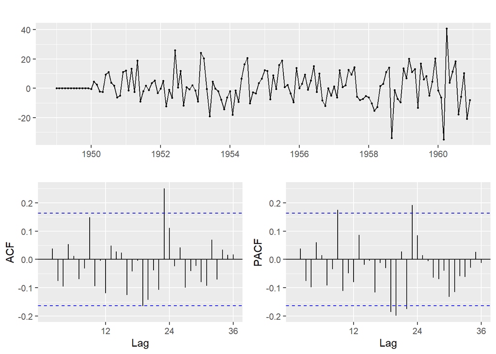

```r
ggtsdisplay(fit_auto$residuals)
```

vemos en los correlogramas que hay observaciones que caen fuera del intervalo de confianza, por lo que éstas son significativas, de este modo podemos pensar que no hay independencia. Para tener más evidencia respecto a tal afirmación, realizamos una prueba de hipótesis

```r
Box.test(fit_auto$residuals)
```

```
##
##  Box-Pierce test
##
## data:  fit_auto$residuals
## X-squared = 0.00022445, df = 1, p-value = 0.988
```

donde no se rechaza $H_{0}$, es decir, no se rechaza que los datos no se correlacionan, en otras palabras, no se encontró evidencia en contra de que los residuales son “independientes”. Podemos realizar la prueba en lags específicos para ver su correlación correspondiente

```r
Box.test(fit_auto$residuals, lag = 12)
```

```
##
##  Box-Pierce test
##
## data:  fit_auto$residuals
## X-squared = 10.208, df = 12, p-value = 0.5978
```

```r
Box.test(fit_auto$residuals, lag = 24)
```

```
##
##  Box-Pierce test
##
## data:  fit_auto$residuals
## X-squared = 32.803, df = 24, p-value = 0.1083
```

donde en ambos no se rechaza $H_{0}$.

Notamos que nuestro modelo es deficiente pues no se están cumpliendo los supuestos sobre los residuos (i.e. que no tenemos un ruido blanco).

Finalmente podemos hacer una prueba de estacionariedad:

```r
adf.test(fit_auto$residuals)
```

```
##
##  Augmented Dickey-Fuller Test
##
## data:  fit_auto$residuals
## Dickey-Fuller = -4.5795, Lag order = 5, p-value = 0.01
## alternative hypothesis: stationary
```

## Caso 2: Transformar la ST

Una vez hecha la transformación logramos estabilizar la varianza. Realizamos nuevamente

```r
fit_auto_t <- auto.arima(log(AirPassengers))
fit_auto_t
```

```
## Series: log(AirPassengers)
## ARIMA(0,1,1)(0,1,1)[12]
##
## Coefficients:
##           ma1     sma1
##       -0.4018  -0.5569
## s.e.   0.0896   0.0731
##
## sigma^2 = 0.001371:  log likelihood = 244.7
## AIC=-483.4   AICc=-483.21   BIC=-474.77
```

donde el nuevo modelo ahora es $ARIMA(0,1,1)(0,1,1)_{12}$ y repetimos el análisis de los supuestos:

1. Normalidad:

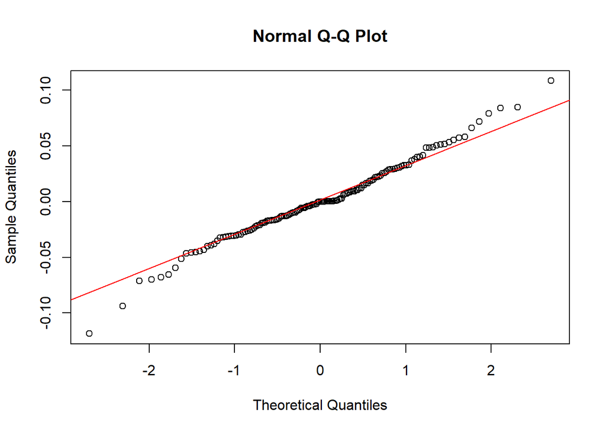

```r
# Q-Q plot
qqnorm(fit_auto_t$residuals)
qqline(fit_auto_t$residuals, col="red")
```

y prueba de hipótesis

```r
ad.test(fit_auto_t$residuals)
```

```
##
##  Anderson-Darling normality test
##
## data:  fit_auto_t$residuals
## A = 0.68703, p-value = 0.07132
```

donde no se rechaza $H_{0}$ (no rechazamos la normalidad).

2. Varianza constante:

```r
# Preparamos los valores
Y <- as.numeric(fit_auto_t$residuals)
X <- 1:length(fit_auto_t$residuals)

# Hacemos las pruebas de hipótesis
bptest(Y ~ X)
```

```
##
##  studentized Breusch-Pagan test
##
## data:  Y ~ X
## BP = 0.31915, df = 1, p-value = 0.5721
```

```r
ncvTest(lm(Y ~ X))
```

```
## Non-constant Variance Score Test
## Variance formula: ~ fitted.values
## Chisquare = 0.4571643, Df = 1, p = 0.49895
```

en ambas prueba no rechazamos $H_{0}$ (no rechazamos que la varianza sea constante).

3. Correlación entre los datos:

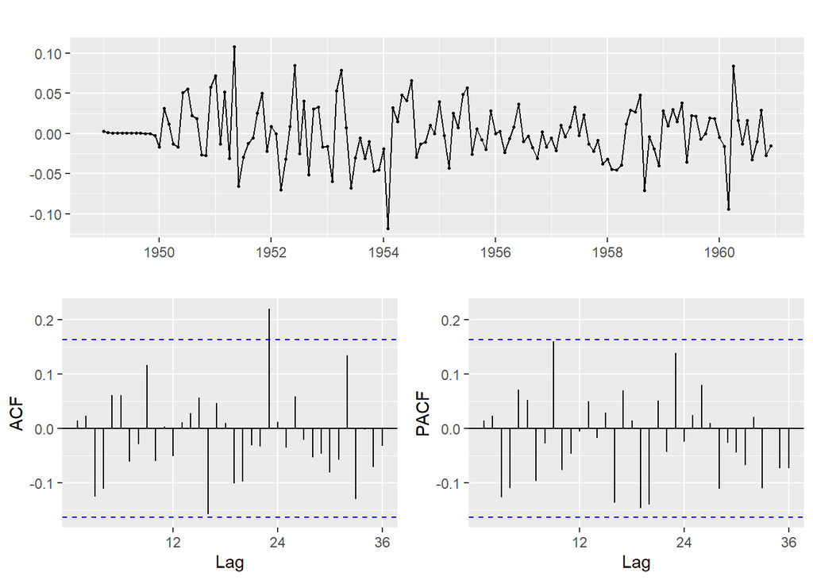

```r
ggtsdisplay(fit_auto_t$residuals)
```

notamos algunos valores en los correlogramas que salen del intervalo de confianza. Nos auxiliamos de la prueba de hipótesis siguiente:

```r
# Utilizamos distintos lags

Box.test(fit_auto$residuals)
```

```
##
##  Box-Pierce test
##
## data:  fit_auto$residuals
## X-squared = 0.00022445, df = 1, p-value = 0.988
```

```r
Box.test(fit_auto$residuals, lag = 1)
```

```
##
##  Box-Pierce test
##
## data:  fit_auto$residuals
## X-squared = 0.00022445, df = 1, p-value = 0.988
```

```r
Box.test(fit_auto$residuals, lag = 24)
```

```
##
##  Box-Pierce test
##
## data:  fit_auto$residuals
## X-squared = 32.803, df = 24, p-value = 0.1083
```

4. Estacionariedad:

```r
adf.test(fit_auto_t$residuals)
```

```
##
##  Augmented Dickey-Fuller Test
##
## data:  fit_auto_t$residuals
## Dickey-Fuller = -4.7907, Lag order = 5, p-value = 0.01
## alternative hypothesis: stationary
```

Tenemos entonces que el modelo $ARIMA(0,1,1)(0,1,1))_{12}$ cumple los supuestos. Tenemos ahora que ver que los parámetros sean estadísticamente significativos. Para ello tenemos que verificar que el o los parámetros sean distintos de cero (o que el cero no esté en el intervalo de confianza):

```r
# Calculamos los intervalos de confianza para las estimaciones de los parámetros
confint(fit_auto_t)
```

```
##           2.5 %     97.5 %
## ma1  -0.5775267 -0.2261293
## sma1 -0.7002176 -0.4136721
```

en ambos casos el cero no pertenece a los intervalos de confianza por lo que ambos parámetros son estadísticamente significativos.

## Criterios de comparación

Consideremos la información del ajuste del modelo hecho a los datos transformados

```r
fit_auto_t
```

```
## Series: log(AirPassengers)
## ARIMA(0,1,1)(0,1,1)[12]
##
## Coefficients:
##           ma1     sma1
##       -0.4018  -0.5569
## s.e.   0.0896   0.0731
##
## sigma^2 = 0.001371:  log likelihood = 244.7
## AIC=-483.4   AICc=-483.21   BIC=-474.77
```

donde

- $AIC=-2 log(verosimilitud)+2p$, con $p$ el número de parámetros estimados. Buscamos un valor menor de $AIC$.

Dichos valores, como el AIC y BIC, sirven para elegir el mejor modelo (los cuales deben cumplir los supuestos).

También podemos ver

```r
summary(fit_auto_t)
```

```
## Series: log(AirPassengers)
## ARIMA(0,1,1)(0,1,1)[12]
##
## Coefficients:
##           ma1     sma1
##       -0.4018  -0.5569
## s.e.   0.0896   0.0731
##
## sigma^2 = 0.001371:  log likelihood = 244.7
## AIC=-483.4   AICc=-483.21   BIC=-474.77
##
## Training set error measures:
##                        ME       RMSE        MAE        MPE      MAPE      MASE
## Training set 0.0005730622 0.03504883 0.02626034 0.01098898 0.4752815 0.2169522
##                    ACF1
## Training set 0.01443892
```

donde $MAE$ (mean absolute error). Estos valores también nos servirán para elegir el mejor modelo.

- Un buen modelo: buscamos donde el error sea menor.

## Comparación de modelos

El modelo que hallamos para los datos transformados no es el único, puede hallarse algunos otros modelos para dicha serie:

```r
# Modelo hallado
fit1 <- arima(log(AirPassengers), c(0,1,1), seasonal = list(order = c(0,1,1), period = 12))

# Alternativas
fit2 <- arima(log(AirPassengers), c(0,1,1), seasonal = list(order = c(2,1,2), period = 12))
fit3 <- arima(log(AirPassengers), c(2,1,1), seasonal = list(order = c(0,1,0), period = 12))
```

Para los ajustes 2 y 3 debemos repetir el proceso que llevamos a cabo para el ajuste 1, es decir, debemos repetir el análisis de los supuesto, para posteriormente comparar y ver cual de los modelos es el mejor utilizando los criterios de comparación.